# Clustering: perfiles de municipios (dataset reutilizado de la Sesión 18)

SESIÓN 20 — OTROS MODELOS Y ENSAMBLES

Autor/a

Jorge Juvenal Campos Ferreira — TC2001B.601

Fecha de publicación

24 de mayo de 2026

```r
options(scipen = 999)
```

El clustering es aprendizaje NO SUPERVISADO: no hay variable objetivo; el objetivo es descubrir grupos de municipios con perfiles socioeconómicos parecidos. Comparamos TRES familias de algoritmos:

1. k-means: parte los datos en k grupos minimizando la distancia de cada punto al centroide de su grupo. Hay que decir cuántos grupos (k) de antemano. Asume grupos “esféricos” de tamaño similar y es sensible a outliers. Todo punto queda asignado a algún grupo (no detecta ruido).
2. Jerárquico aglomerativo (hclust + cutree): empieza con cada punto como su propio grupo y va fusionando los más cercanos hasta tener un único grupo, construyendo un dendrograma (árbol). Con cutree() “cortamos” el árbol a la altura que da k grupos. No exige fijar k antes de calcular; el dendrograma ayuda a elegirlo. Usamos enlace de Ward (ward.D2), que tiende a formar grupos compactos y de tamaño parecido.
3. DBSCAN (dbscan): agrupa por DENSIDAD. No fija k: descubre tantos grupos como regiones densas haya y marca como RUIDO (cluster 0) los puntos en zonas poco densas. Dos hiperparámetros:
- eps: radio de vecindad. Qué tan cerca deben estar dos puntos para considerarse vecinos.
- minPts: mínimo de puntos dentro de eps para que una zona se considere densa (semilla de un grupo). Es el único de los tres que detecta outliers explícitamente y encuentra grupos de forma arbitraria (no esféricos).

REGLA DE ORO: en TODOS hay que NORMALIZAR primero. Las variables están en escalas muy distintas (porcentajes 0-100, ingreso en miles de pesos, densidad hasta ~2,500 hab/km2). Sin estandarizar, la densidad y el ingreso dominarían las distancias euclidianas y los grupos solo reflejarían esas dos variables.

```r
# Librerías (todas al inicio)
library(tidyverse)
library(tidymodels)
library(dbscan)
library(factoextra)
library(cluster)
```

```r
tidymodels_prefer()
```

## 1. Cargar los datos

```r
# Guardamos la clave del municipio aparte (es identificador, no variable de
# agrupamiento) y la removemos de la matriz que entra a los algoritmos.
municipios <- read_csv("datos.csv")
```

```r
claves_municipio <- municipios %>% select(clave_municipio)
```

```r
municipios_vars <- municipios %>%
  select(-clave_municipio)
```

```r
# NAs por columna
summary(municipios_vars)
```

```
  pct_pobreza    pct_carencia_educativa pct_carencia_salud ingreso_promedio_mxn
 Min.   : 8.56   Min.   : 1.00          Min.   : 1.00      Min.   : 1500
 1st Qu.:31.60   1st Qu.:19.29          1st Qu.:22.88      1st Qu.: 4410
 Median :46.94   Median :33.26          Median :38.16      Median : 6936
 Mean   :49.02   Mean   :35.42          Mean   :39.32      Mean   : 8050
 3rd Qu.:65.42   3rd Qu.:51.72          3rd Qu.:56.22      3rd Qu.:11414
 Max.   :99.00   Max.   :76.95          Max.   :80.78      Max.   :19280
                                                           NA's   :20
 pct_poblacion_rural pct_acceso_internet densidad_pob_km2  tasa_alfabetizacion
 Min.   :  0.00      Min.   : 1.00       Min.   :   1.00   Min.   : 61.07
 1st Qu.: 23.70      1st Qu.:24.04       1st Qu.:  54.97   1st Qu.: 77.41
 Median : 43.29      Median :45.49       Median : 172.48   Median : 87.10
 Mean   : 49.11      Mean   :45.38       Mean   : 428.54   Mean   : 85.32
 3rd Qu.: 76.68      3rd Qu.:67.25       3rd Qu.: 567.30   3rd Qu.: 94.20
 Max.   :100.00      Max.   :99.00       Max.   :2504.16   Max.   :100.00

 grado_marginacion_idx
 Min.   :0.140
 1st Qu.:0.550
 Median :0.890
 Mean   :0.943
 3rd Qu.:1.302
 Max.   :1.750
```

```r
# ingreso_promedio_mxn: ~20 NAs
```

## 2. Normalización (paso OBLIGATORIO) con una receta

```r
# Usamos una receta solo para preprocesar (no hay modelo supervisado aquí):
#  (1) step_impute_median: en clustering no podemos dejar NAs (romperían todas
#      las distancias). Imputamos ingreso_promedio_mxn con la mediana.
#  (2) step_normalize: z-score de todas las variables numéricas.
# Nota sobre colinealidad: grado_marginacion_idx está muy correlacionado con
# pct_pobreza; lo dejamos por simplicidad, pero hay que recordar que esa
# dimensión queda algo sobre-ponderada en las distancias.
receta_municipios <- recipe(~ ., data = municipios_vars) %>%
  step_impute_median(all_numeric_predictors()) %>%
  step_normalize(all_numeric_predictors())
```

```r
# Preparamos y aplicamos la receta: obtenemos la matriz estandarizada que
# alimentará a los tres algoritmos.
municipios_norm <- receta_municipios %>%
  prep() %>%
  bake(new_data = NULL)
```

```r
# Vistazo a los datos estandarizados (media ~0, desviación ~1)
summary(municipios_norm)
```

```
  pct_pobreza       pct_carencia_educativa pct_carencia_salud
 Min.   :-1.89545   Min.   :-1.8246        Min.   :-1.97257
 1st Qu.:-0.81612   1st Qu.:-0.8553        1st Qu.:-0.84651
 Median :-0.09755   Median :-0.1147        Median :-0.05943
 Mean   : 0.00000   Mean   : 0.0000        Mean   : 0.00000
 3rd Qu.: 0.76850   3rd Qu.: 0.8642        3rd Qu.: 0.86986
 Max.   : 2.34175   Max.   : 2.2016        Max.   : 2.13425
 ingreso_promedio_mxn pct_poblacion_rural pct_acceso_internet densidad_pob_km2
 Min.   :-1.4484      Min.   :-1.6839     Min.   :-1.781633   Min.   :-0.8119
 1st Qu.:-0.7904      1st Qu.:-0.8711     1st Qu.:-0.856611   1st Qu.:-0.7095
 Median :-0.2383      Median :-0.1995     Median : 0.004382   Median :-0.4863
 Mean   : 0.0000      Mean   : 0.0000     Mean   : 0.000000   Mean   : 0.0000
 3rd Qu.: 0.6450      3rd Qu.: 0.9455     3rd Qu.: 0.878121   3rd Qu.: 0.2635
 Max.   : 2.5101      Max.   : 1.7450     Max.   : 2.152498   Max.   : 3.9418
 tasa_alfabetizacion grado_marginacion_idx
 Min.   :-2.3109     Min.   :-1.8358
 1st Qu.:-0.7537     1st Qu.:-0.8984
 Median : 0.1698     Median :-0.1211
 Mean   : 0.0000     Mean   : 0.0000
 3rd Qu.: 0.8465     3rd Qu.: 0.8220
 Max.   : 1.3992     Max.   : 1.8452
```

## 3. ¿Cuántos clusters? Método del codo para orientar k

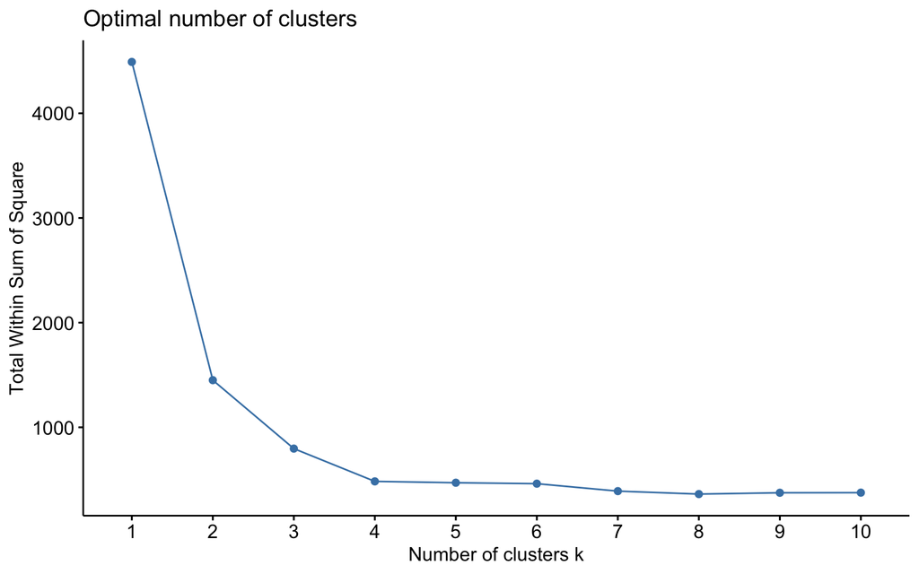

```r
# fviz_nbclust con el método "wss" (within sum of squares) grafica la suma de
# distancias internas contra k. Buscamos el "codo": el punto donde agregar más
# grupos ya no reduce mucho la dispersión interna. Esperamos ~4 perfiles.
set.seed(2020)
grafico_codo <- fviz_nbclust(municipios_norm, kmeans, method = "wss",
                             k.max = 10)
grafico_codo
```

```r
# A partir del codo (y del contexto: ~4 perfiles latentes de municipios)
# fijamos k = 4 para k-means y para el corte del jerárquico.
k_grupos <- 4
```

## 4. MÉTODO 1: k-means

```r
# nstart = 25: k-means depende del azar (centroides iniciales); con 25
# arranques nos quedamos con la mejor solución. centers = k_grupos.
set.seed(2020)
modelo_kmeans <- kmeans(municipios_norm, centers = k_grupos, nstart = 25)
```

```r
# Tamaño de cada cluster
cluster_kmeans <- modelo_kmeans$cluster
table(cluster_kmeans)
```

```
cluster_kmeans
  1   2   3   4
120 142 110 128
```

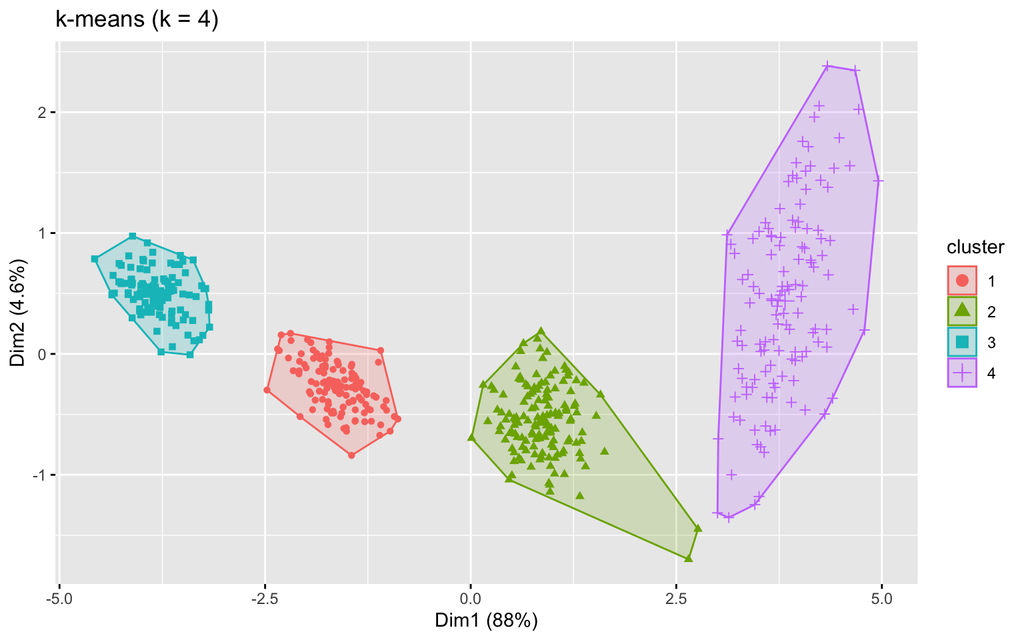

```r
# Visualización en el plano de las dos primeras componentes principales
fviz_cluster(modelo_kmeans, data = municipios_norm,
             geom = "point",
             main = "k-means (k = 4)")
```